# Citation Network Analysis of a Computer Science Conference

Clement Lee (Lancaster University)

2020-02-28 (Fri)

# Background

- Previously statistics postdoc at Newcastle University
- Open Lab: [openlab.ncl.ac.uk](https://openlab.ncl.ac.uk/)
- World leading research group in
  - Human Computer Interaction (HCI)
  - Digital Civics
  - Ubiquitous Computing

# Themes

#### Digital Civics

- Community health: [Feed Finder](https://feed-finder.co.uk/), [App Movement](https://app-movement.com/)
- Education: [Learning Circle](https://learningcircle.io/)
- Social care, public health, local democracy…

#### Human-Computer Interaction (HCI)

- Designing digital technology with people in mind
- ACM CHI Conference on Human Factors in Computing Systems

# Digital library

- dl.acm.org
- All publications of ACM (journals, conference proceedings …)
- What if we scrape and analyse the data?

[figure not shown]

(Source: xkcd.com/1683/)

# Old wine in a new bottle

- Bibliometrics is old
- Works within CHI

| Authors | Year | Digital Library ID |
| --- | --- | --- |
| Bartneck and Hu | 2009 | 1518810 |
| Kaye | 2009 | 1520364 |
| Matejka *et al.* | 2012 | 2212796 |
| Liu *et al.* | 2014 | 2556969 |
| Padilla *et al.* | 2014 | 2578867 |
| Pohl and Mottelson | 2019 | 3310429 |
| Lee *et al.* | 2019 | 3312776 |

# Current approaches

- Text approach
  - Changing meanings of words
  - Some words dominating the field, e.g. “design”, “user”, etc.
- Network approach
  - Focus usually on collaboration networks
- Availability of data
  - Other databases not very helpful
  - Or require quite some manual scraping

# Scope

- Gather the references of all CHI papers from 1981 to 2019
  - Digital Library ID useful for identifying papers
- Construct citation network within ~7000 papers
  - Well defined boundary
- Cluster the papers
  - Using methods for social networks
- Examine the groups
  - Do they represent different topics/themes?
  - How is the trend over the years?

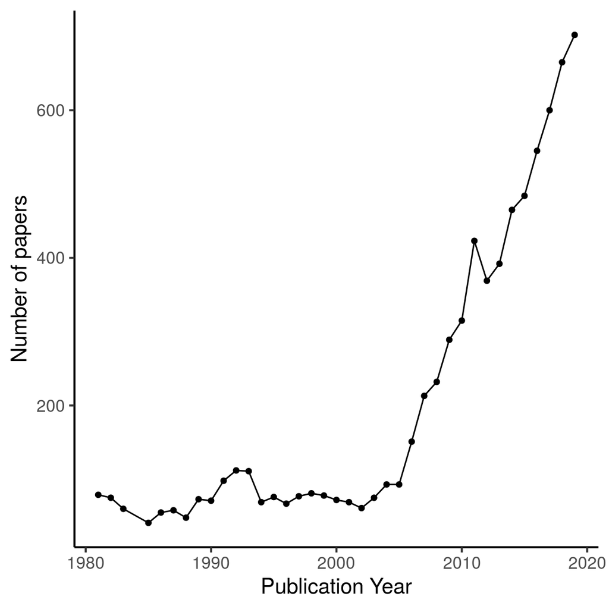

# Scope

- Gather the references of all CHI papers from 1981 to 2019
  - Digital Library ID useful for identifying papers
- Construct citation network within ~7000 papers
  - Well defined boundary
- Cluster the papers
  - Using methods for social networks
- Examine the groups
  - Do they represent different topics/themes?
  - How is the trend over the years?

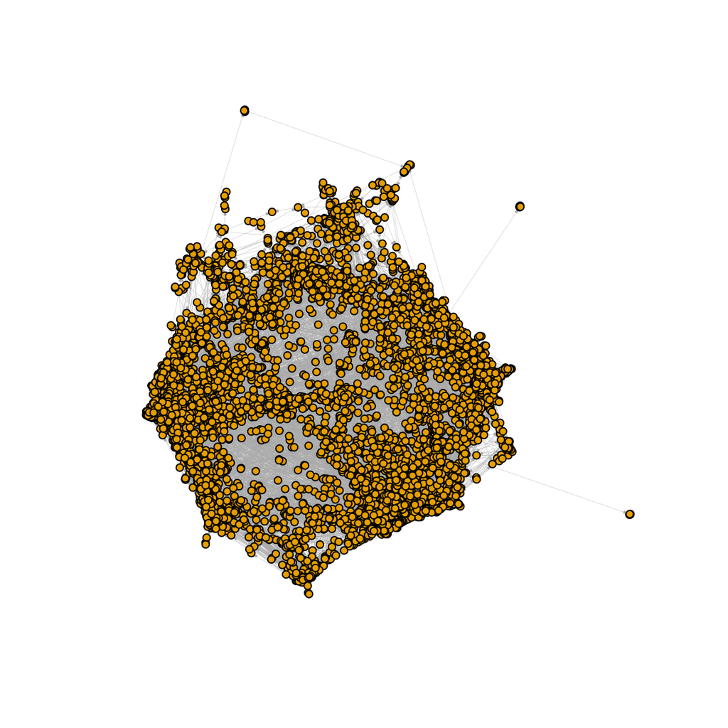

# Community detection

- **Algorithms** for clustering relational data
- Principles based on heuristics
- Pros
  1. Quick
- Cons
  1. Huge inequality in group sizes
  2. Variation of results between algorithms
  3. Number of groups?
  4. Resolution limit

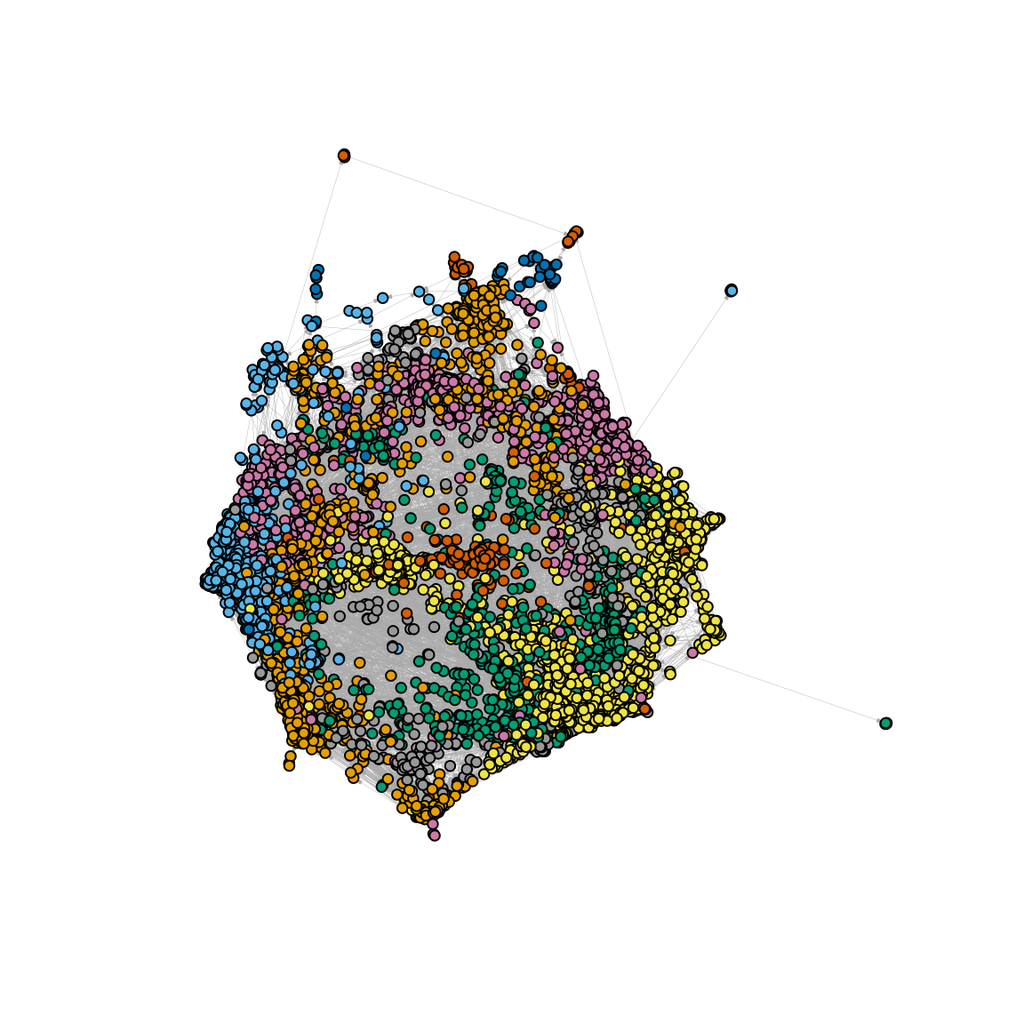

# Stochastic block models

- **Statistical models** for clustering relational data
- Properly defined by model assumptions
- Pros
  1. One definitive set of results (theoretically)
  2. Can resolve issues with community detection
- Cons
  1. Not off the shelf
  2. Slow / difficult to scale

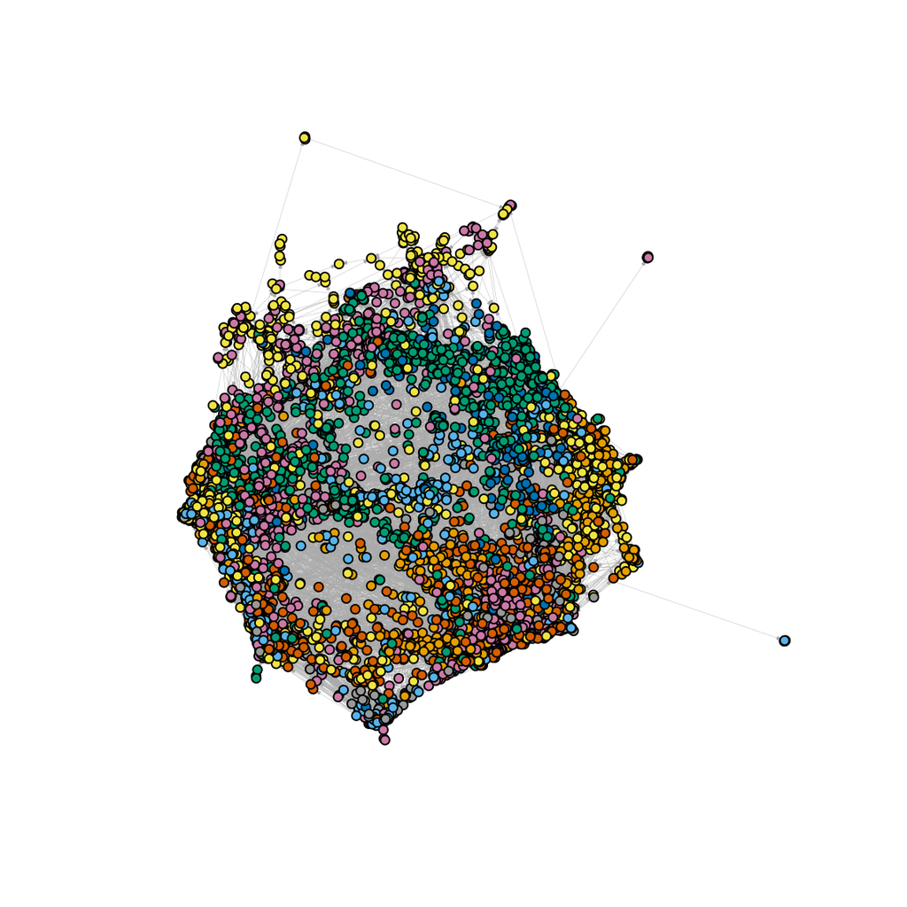

# Difference

- Community detection
  - Nodes (papers) are tightly connected **within** each group
  - Low connectivity **between** groups
- Stochastic block models
  - Same connectivity for any pair of nodes in two groups
  - Not guaranteed to be high or low
  - Existence of miscellaneous group

# Statistical models

- Slightly different way of looking at the data
  - Computational/physical: input the parameters, output simulated data
  - Statistical: input real data, output (estimates of) the parameters
- Linear regression
  - Parameters: slope and intercept
- Epidemic modelling
  - Parameters: transmission rate, basic reproduction number, …
  - Say something about when individuals get infected

# Inferring hidden structure

- … is not trivial
- Always comes with some degree of uncertainty
- Label switching
  - (A, B, C) in group 1; (D, E) in group 2
  - (D, E) in group 1; (A, B, C) in group 2

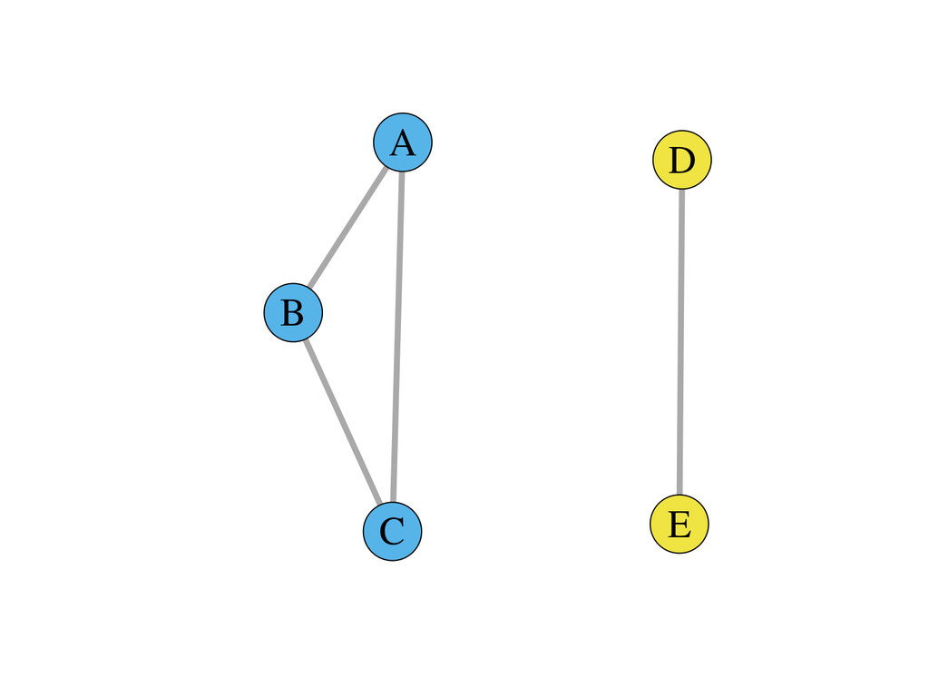

# Utilising extra information

- Publication years available
- Forcing the “mean” year to be increasing for groups
  - Mean of group 1 $<$ mean of group 2 $<\cdots$
  - Smaller groups (labels, not sizes) represent earlier topics
  - The group labels are actually interpretable

# Results

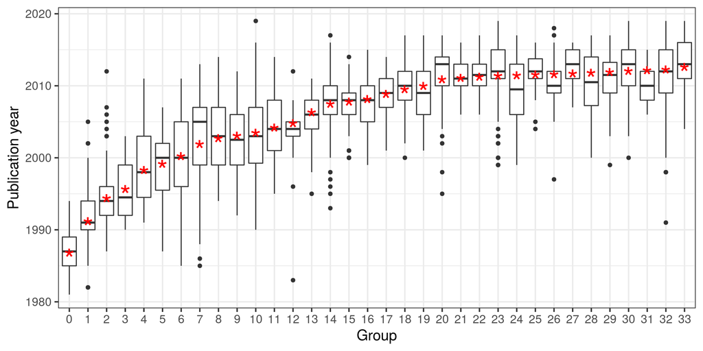

# Results (more interesting ones)

- [A simple web app](https://clement-lee.shinyapps.io/chi_groups/)

# A new direction

- Directed Acyclic Graph (DAG)
  - No cycles of any length
  - Start with any node A and travel along the edges
  - Impossible to go back to node A

[figure not shown]

(Source: en.wikipedia.org/wiki/Directed_acyclic_graph)

# Common as models

- Bayesian networks
- Probabilistic graphical models
- Examples
  - Kocabas, V. and Dragicevic, S. (2007), Enhancing a GIS Cellular Automata Model of Land Use Change: Bayesian Networks, Influence Diagrams and Causality. Transactions in GIS, 11: 681-702.
  - Roos, J., Gavin, G., and Bonnevay, S. (2017), A dynamic Bayesian network approach to forecast short-term urban rail passenger flows with incomplete data. Transportation Research Procedia, 26: 53-61.

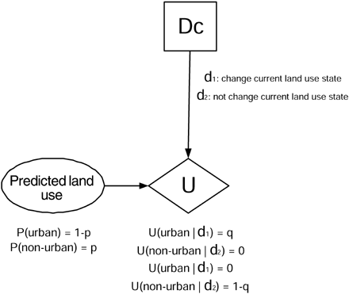

(Source: [Kocabas and Dragicevic (2007)](https://doi.org/10.1111/j.1467-9671.2007.01066.x))

# Not so common as data *being modelled*

- Examples
  - Cells in a spreadsheet

[figure not shown]

(Source: lynda.com/Excel-Mac-tutorials/Track-cell-dependencies-locate-formula-sources/431189/498037-4.html)

# Not so common as data *being modelled*

- Examples
  - Cells in a spreadsheet
  - River networks

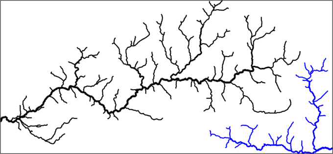

(Source: topotoolbox.wordpress.com/2017/03/13/)

# Not so common as data *being modelled*

- Examples
  - Cells in a spreadsheet
  - River networks
  - File/project/software dependencies

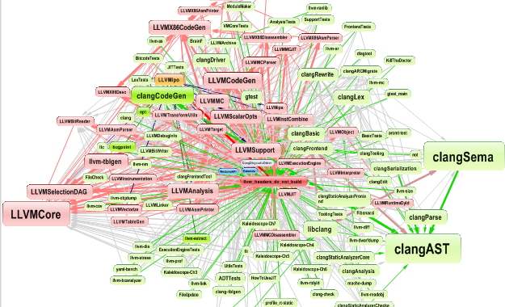

(Source: javadepend.com/Blog/?p=2328)

# What next?

- Incorporating the fact that “the data is a DAG” into the model
  - Not as trivial as incorporating the publication years
  - How to order the groups? What meanings do they have?
- Incorporating the text and/or collaboration network into the model
  - Same ultimate goal of clustering
  - Potentially reduces statistical uncertainty